## Import Libraries

```python
import pandas as pd
import matplotlib.pyplot as plt
import seaborn as sns
import numpy as np
%matplotlib inline
```

# Read the dataframe, rename header assign the column names

```python
data = pd.read_csv("ratings_Electronics.csv", header = None, names = ['userid', 'productid','ratings', 'timestamp'])
```

```python
data.drop('timestamp', axis = 1, inplace = True)
```

## Data Characteristics

```python
data.head()
```

|  | userid | productid | ratings |
| --- | --- | --- | --- |
| 0 | AKM1MP6P0OYPR | 0132793040 | 5.0 |
| 1 | A2CX7LUOHB2NDG | 0321732944 | 5.0 |
| 2 | A2NWSAGRHCP8N5 | 0439886341 | 1.0 |
| 3 | A2WNBOD3WNDNKT | 0439886341 | 3.0 |
| 4 | A1GI0U4ZRJA8WN | 0439886341 | 1.0 |

```python
data.dtypes
```

```
userid        object
productid     object
ratings      float64
dtype: object
```

```python
data['userid'] = data['userid'].astype(str)
data['productid'] = data['productid'].astype(str)
```

```python
data.shape
```

```
(7824482, 3)
```

### Check for missing values

No missing values

```python
data.isnull().sum()
```

```
userid       0
productid    0
ratings      0
dtype: int64
```

### Ratings Histogram

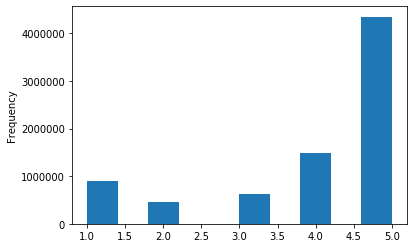

```python
data['ratings'].plot(kind = 'hist')
```

### Ratings Countplot

We find that many of the items has received a rating of 5 from the users.

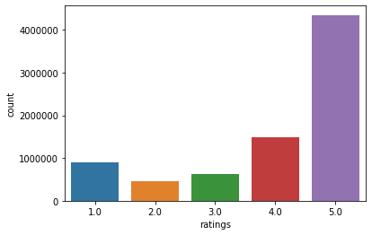

```python
sns.countplot(data['ratings'])
```

### Unique Users and Products

```python
print('There are {} unique users'.format(len(data['userid'].unique())))
print('There are {} unique items'.format(len(data['productid'].unique())))
```

```
There are 4201696 unique users
There are 476002 unique items
```

### Ratings Column Statistics

Mean rating is 4.012. Median rating is 5. Min rating is 1 and the max rating is 5.

```python
data['ratings'].describe().transpose().round(3)
```

```
count    7824482.000
mean           4.012
std            1.381
min            1.000
25%            3.000
50%            5.000
75%            5.000
max            5.000
Name: ratings, dtype: float64
```

# Create a dense, less sparse matrix

We will create a dataframe containing the Users with minimum 50 ratings

```python
data.groupby('userid').size().sort_values(ascending = False)[:100]
```

```
userid
A5JLAU2ARJ0BO     520
ADLVFFE4VBT8      501
A3OXHLG6DIBRW8    498
A6FIAB28IS79      431
A680RUE1FDO8B     406
                 ...
A3W4D8XOGLWUN5    153
A32O5FZH994CNY    151
A17HMM1M7T9PJ1    151
A225G2TFM76GYX    150
A2WB7LZ595CR50    149
Length: 100, dtype: int64
```

```python
df = data.copy()
```

```python
counts = df['userid'].value_counts()
```

```python
df = df[df['userid'].isin(counts[counts>=50].index)]
```

```python
print("Number of users who rated items or more are: {}".format(df.shape[0]))
print("Unique Users are {}".format(len(df['userid'].unique())))
print("Unique Items are {}".format(len(df['productid'].unique())))
```

```
Number of users who rated items or more are: 125871
Unique Users are 1540
Unique Items are 48190
```

```python
final = df.pivot(index = 'userid', columns = 'productid', values = 'ratings').fillna(0)
```

```python
print("Shape of final ratings matrix: ", final.shape)
number_of_ratings = np.count_nonzero(final)
print("Number of ratings given = ", number_of_ratings)
possible_ratings = final.shape[0]*final.shape[1]
print("Possible ratings = ", possible_ratings)
density = (number_of_ratings/possible_ratings)
density *=100
print("Density: {:4.2f}%".format(density))
```

```
Shape of final ratings matrix:  (1540, 48190)
Number of ratings given =  125871
Possible ratings =  74212600
Density: 0.17%
```

# Popularity Recommendation Model

```python
final_grouped = df.groupby('productid').agg({'userid': 'count'}).reset_index()
final_grouped.rename(columns = {'userid': 'score'}, inplace = True)
```

```python
final_grouped = final_grouped.sort_values(['score', 'productid'], ascending = [0,1])
final_grouped['rank'] = final_grouped['score'].rank(ascending = 0, method = 'first')
```

### Top 5 Recommendations

```python
final_grouped.head(5)
```

|  | productid | score | rank |
| --- | --- | --- | --- |
| 39003 | B0088CJT4U | 206 | 1.0 |
| 24827 | B003ES5ZUU | 184 | 2.0 |
| 11078 | B000N99BBC | 167 | 3.0 |
| 38250 | B007WTAJTO | 164 | 4.0 |
| 38615 | B00829TIEK | 149 | 5.0 |

# Split the data randomly into a train and test dataset.

### Using Surprise library, we will split the data and use for collaborative filtering approach

```python
from surprise import Dataset, Reader
```

```python
reader = Reader(rating_scale=(1,5))
```

```python
data = Dataset.load_from_df(df[['userid', 'productid','ratings']],reader)
```

```python
from surprise.model_selection import train_test_split
trainset, testset = train_test_split(data, test_size= 0.30,random_state=1)
```

# Collaborative Filtering Approach

```python
from surprise import KNNWithMeans
from surprise import accuracy
```

```python
algo = KNNWithMeans(k = 50, sim_options={'name':'pearson', 'user_based': True})
algo.fit(trainset)
```

```
Computing the pearson similarity matrix...
Done computing similarity matrix.
```

```
<surprise.prediction_algorithms.knns.KNNWithMeans at 0x1052c91d0>
```

```python
test_pred = algo.test(testset)
```

### RMSE for KNNwithMeans method

```python
accuracy.rmse(test_pred)
accuracy.mae(test_pred)
```

```
RMSE: 1.0465
MAE:  0.7792
```

```
0.7792096199442866
```

### Converting to a dataframe

```python
test_pred_df = pd.DataFrame(test_pred)
```

```python
test_pred_df['was_impossible'] = [x["was_impossible"] for x in test_pred_df['details']]
```

```python
test_pred_df
```

|  | uid | iid | r_ui | est | details | was_impossible |
| --- | --- | --- | --- | --- | --- | --- |
| 0 | A3PDWA32BAMB2Y | B00CGW74YU | 5.0 | 4.385965 | {'actual_k': 0, 'was_impossible': False} | False |
| 1 | A31BD4RXCON7QO | B000P6G7YW | 1.0 | 4.259735 | {'was_impossible': True, 'reason': 'User and/o... | True |
| 2 | A3J8A5L5AF5TX9 | B001GS8G06 | 1.0 | 3.935484 | {'actual_k': 0, 'was_impossible': False} | False |
| 3 | A3D6OI36USYOU1 | B000A1790S | 5.0 | 4.259735 | {'was_impossible': True, 'reason': 'User and/o... | True |
| 4 | A3JU16JTNLVK1J | B002CX16WO | 2.0 | 4.259735 | {'was_impossible': True, 'reason': 'User and/o... | True |
| ... | ... | ... | ... | ... | ... | ... |
| 37757 | A3R1WFO4KIUQXZ | B002SQK2F2 | 5.0 | 2.365568 | {'actual_k': 7, 'was_impossible': False} | False |
| 37758 | A19NP8YYADOOSF | B008DWCRQW | 4.0 | 3.328021 | {'actual_k': 7, 'was_impossible': False} | False |
| 37759 | ACHTDPEQYSEQL | B00008ELLG | 4.0 | 4.259735 | {'was_impossible': True, 'reason': 'User and/o... | True |
| 37760 | A7EU2BWLLCJY2 | B0055E8B0M | 2.0 | 4.259735 | {'was_impossible': True, 'reason': 'User and/o... | True |
| 37761 | A3QUDXLOJTKEP9 | B008HIZ0FW | 5.0 | 4.431818 | {'actual_k': 0, 'was_impossible': False} | False |

37762 rows × 6 columns

### Make Predictions

```python
algo.predict(uid='A19NP8YYADOOSF', iid = 'B00CGW74YU')
```

```
Prediction(uid='A19NP8YYADOOSF', iid='B00CGW74YU', r_ui=None, est=4.0, details={'actual_k': 0, 'was_impossible': False})
```

### Top 10 Predictions

```python
testset_new = trainset.build_anti_testset()
```

```python
predictions = algo.test(testset_new[0:1000])
```

```python
predictions_df = pd.DataFrame([[x.uid, x.iid,  x.est]for x in predictions])
```

```python
predictions_df.columns = ['userid', 'productid', 'est_rating']
predictions_df.sort_values(by = ['userid', 'est_rating'], ascending = False, inplace = True)
```

```python
predictions_df.groupby('userid').head(10).reset_index(drop = True)
```

|  | userid | productid | est_rating |
| --- | --- | --- | --- |
| 0 | A2CIQEY05SPHTZ | B008ULPE70 | 5.000000 |
| 1 | A2CIQEY05SPHTZ | B008X9Z7N0 | 5.000000 |
| 2 | A2CIQEY05SPHTZ | B00AEKEA48 | 5.000000 |
| 3 | A2CIQEY05SPHTZ | B00125Y0NU | 5.000000 |
| 4 | A2CIQEY05SPHTZ | B00IF0JAIU | 5.000000 |
| 5 | A2CIQEY05SPHTZ | B002K9IHGI | 4.988205 |
| 6 | A2CIQEY05SPHTZ | B00ENZRS76 | 4.987333 |
| 7 | A2CIQEY05SPHTZ | B005LIDMYM | 4.955301 |
| 8 | A2CIQEY05SPHTZ | B00BGGDVOO | 4.948670 |
| 9 | A2CIQEY05SPHTZ | B0002LEMWE | 4.948670 |

## SVD Based Recommendation

```python
from surprise import SVD
from surprise import accuracy
```

```python
svd_model = SVD(n_factors=50,biased = False)
svd_model.fit(trainset)
test_pred_svd = svd_model.test(testset)
```

### RMSE for SVD

```python
accuracy.rmse(test_pred_svd)
accuracy.mae(test_pred_svd)
```

```
RMSE: 2.0752
MAE:  1.6771
```

```
1.6771142527819778
```

```python
test_pred_svd[20]
```

```
Prediction(uid='ALHC64J88LVWO', iid='B00C2P61FO', r_ui=5.0, est=2.000201272099357, details={'was_impossible': False})
```

### Parameter tuning for SVD

```python
from surprise.model_selection import GridSearchCV
param_grid = {'n_factors' : [5,10,15], "reg_all":[0.01,0.02]}
gs = GridSearchCV(SVD, param_grid, measures=['rmse'], cv=3,refit = True)
```

```python
gs.fit(data)
```

```python
gs.param_combinations
```

```
[{'n_factors': 5, 'reg_all': 0.01},
 {'n_factors': 5, 'reg_all': 0.02},
 {'n_factors': 10, 'reg_all': 0.01},
 {'n_factors': 10, 'reg_all': 0.02},
 {'n_factors': 15, 'reg_all': 0.01},
 {'n_factors': 15, 'reg_all': 0.02}]
```

```python
gs.best_params
```

```
{'rmse': {'n_factors': 5, 'reg_all': 0.02}}
```

### Buiding with best params and RMSE for SVD after Hyper Tuning

```python
svd_model = SVD(n_factors=5,reg_all = 0.02, biased = False)
svd_model.fit(trainset)
test_pred_svd = svd_model.test(testset)
accuracy.rmse(test_pred_svd)
accuracy.mae(test_pred_svd)
```

```
RMSE: 1.7340
MAE:  1.3119
```

```
1.3118723444738072
```

```python
test_pred_svd = pd.DataFrame(test_pred_svd)
test_pred_svd.head(10)
```

|  | uid | iid | r_ui | est | details |
| --- | --- | --- | --- | --- | --- |
| 0 | A3PDWA32BAMB2Y | B00CGW74YU | 5.0 | 2.179987 | {'was_impossible': False} |
| 1 | A31BD4RXCON7QO | B000P6G7YW | 1.0 | 4.259735 | {'was_impossible': True, 'reason': 'User and i... |
| 2 | A3J8A5L5AF5TX9 | B001GS8G06 | 1.0 | 1.661677 | {'was_impossible': False} |
| 3 | A3D6OI36USYOU1 | B000A1790S | 5.0 | 4.259735 | {'was_impossible': True, 'reason': 'User and i... |
| 4 | A3JU16JTNLVK1J | B002CX16WO | 2.0 | 4.259735 | {'was_impossible': True, 'reason': 'User and i... |
| 5 | A1ZU55TM45Y2R8 | B00HFAEBWG | 3.0 | 3.785778 | {'was_impossible': False} |
| 6 | AYP0YPLSP9ISM | B006Z0Q2SI | 3.0 | 2.761698 | {'was_impossible': False} |
| 7 | A3UR2N0ATGBCU8 | B0024NL4DI | 5.0 | 4.259735 | {'was_impossible': True, 'reason': 'User and i... |
| 8 | A1PM7HH4F77NEH | B003D3MFHM | 5.0 | 4.259735 | {'was_impossible': True, 'reason': 'User and i... |
| 9 | A1SFPA80X7TRBR | B001FXZTIY | 5.0 | 3.291324 | {'was_impossible': False} |

## Top 10 Recommendation from SVD

```python
testset_new = testset_new[:1000]
svd_pred = svd_model.test(testset_new)
```

```python
svd_pred_df = pd.DataFrame([[x.uid, x.iid, x.est] for x in svd_pred])
svd_pred_df.columns = ['userid', 'productid', 'est_rating']
svd_pred_df.sort_values(['userid', 'est_rating'], ascending = False, inplace = True)
svd_pred_df.groupby('userid').head(10).reset_index(drop = True)
```

|  | userid | productid | est_rating |
| --- | --- | --- | --- |
| 0 | A2CIQEY05SPHTZ | B009NB8WR0 | 5.0 |
| 1 | A2CIQEY05SPHTZ | B008MDSWI4 | 5.0 |
| 2 | A2CIQEY05SPHTZ | B001NS828K | 5.0 |
| 3 | A2CIQEY05SPHTZ | B000N99BBC | 5.0 |
| 4 | A2CIQEY05SPHTZ | B00IVPU786 | 5.0 |
| 5 | A2CIQEY05SPHTZ | B000CRFOMK | 5.0 |
| 6 | A2CIQEY05SPHTZ | B001ENW61I | 5.0 |
| 7 | A2CIQEY05SPHTZ | B00D6XW62I | 5.0 |
| 8 | A2CIQEY05SPHTZ | B005ES0YYA | 5.0 |
| 9 | A2CIQEY05SPHTZ | B0048IW030 | 5.0 |

# Evaluate the Model & Insights

KNNwithMeans - RMSE: 1.0465 and MAE: 0.7792  
SVD without HyperParameter Tuning - RMSE: 2.0752 and MAE: 1.6771  
SVD after HyperParameter Tuning RMSE: 1.7340 and MAE: 1.3119  
We find that KNNWithMeans is the best for User - User Collaborative model since it has the least RMSE and MAE  
While creating a dense matrix, we were able to achieve 0.17% only while taking the minimum number of ratings given by the user as 50  
We had the Unique Users are 1540 and Unique Items are 48190  
Model-based Collaborative Filtering is a personalised recommender system, the recommendations are based on the past behavior of the user and it is not dependent on any additional information.

The Popularity-based recommender system is non-personalised and the recommendations are based on frequecy counts, which may be not suitable to the user.